# MaxDiff Analysis of MSBA Class Preferences

Counts, MLE, and Bayesian estimation of the MNL model

Author

Corrine

Published

May 28, 2026

## Introduction

This report analyzes MSBA students’ preferences across the 10 core MSBA courses at UC San Diego Rady School of Management, using data collected via a **MaxDiff** (Best-Worst Scaling) survey.

**What is MaxDiff?** MaxDiff is a survey methodology designed to measure how strongly people prefer one item over another. Rather than asking respondents to rate items on a numeric scale, MaxDiff presents a small subset of items (here, 4) on each screen and asks respondents to select the *most preferred* and *least preferred* item. This repeats over many screens with different item combinations.

**Why MaxDiff instead of a rating scale?** Humans are good at trade-off judgments — picking the best and worst from a small set — but unreliable at calibrating numeric scales consistently. MaxDiff forces real differentiation between items and eliminates scale-use bias.

**Goals:** We estimate students’ relative preference for each of the 10 labeled MSBA classes using three methods of increasing sophistication:

1. A simple **counts analysis** — % times picked best minus % times picked worst
2. The **MNL model** fit by **maximum likelihood (MLE)** — a probabilistic model that uses all the data more efficiently
3. The same MNL model fit by **Bayesian MCMC** (Metropolis-Hastings) — which adds principled uncertainty quantification

All three methods should broadly agree on the ranking; they differ in statistical rigor and how they communicate uncertainty.

## The Data

```python
import pandas as pd
import numpy as np
import matplotlib.pyplot as plt
import warnings
warnings.filterwarnings('ignore')

# Load raw data
df_raw = pd.read_csv("maxdiff_design_and_choices.csv")
df_raw.columns = ["record_id", "task", "position", "item", "response"]

labels_raw = pd.read_csv("maxdiff_item_labels.csv", usecols=[0, 1])
labels_raw.columns = ["item", "label"]

short_labels = {
    1:  "AI Math & Prog (403)",
    2:  "SQL (464)",
    3:  "Mkt/Fin/Ops (451)",
    4:  "Large Data (452)",
    5:  "Biz Analytics (453)",
    6:  "Analytics Consulting (444)",
    7:  "Customer Analytics (455)",
    8:  "Capstone (454)",
    9:  "Mktg Analytics (495)",
    10: "Biz Intel Systems (457)",
}
labels_raw["short"] = labels_raw["item"].map(short_labels)

# The raw data contains an item 11 which has no label in the labels file.
# We remove all tasks that contain item 11 before analysis.
bad_tasks = df_raw[df_raw["item"] == 11][["record_id", "task"]].drop_duplicates()
df = (df_raw
      .merge(bad_tasks, on=["record_id", "task"], how="left", indicator=True)
      .query('_merge == "left_only"')
      .drop(columns="_merge")
      .reset_index(drop=True))

print(f"Tasks removed (contained unlabeled item 11): {len(bad_tasks)}")
print(f"Tasks remaining:                             {df.groupby(['record_id','task']).ngroups}")
df.head(6)
```

```
Tasks removed (contained unlabeled item 11): 595
Tasks remaining:                             680
```

|  | record_id | task | position | item | response |
| --- | --- | --- | --- | --- | --- |
| 0 | 69fb85fbd66b452e6decf4f7 | 1 | 1 | 5 | 0 |
| 1 | 69fb85fbd66b452e6decf4f7 | 1 | 2 | 7 | 1 |
| 2 | 69fb85fbd66b452e6decf4f7 | 1 | 3 | 4 | 0 |
| 3 | 69fb85fbd66b452e6decf4f7 | 1 | 4 | 1 | -1 |
| 4 | 69fb85fbd66b452e6decf4f7 | 2 | 1 | 8 | -1 |
| 5 | 69fb85fbd66b452e6decf4f7 | 2 | 2 | 3 | 0 |

```python
print(df["item"].unique())
print(11 in df["item"].values)
```

```
[ 5  7  4  1  8  3 10  9  2  6]
False
```

```python
N     = df["record_id"].nunique()
T_per = df.groupby("record_id")["task"].nunique().mean()
J     = df.groupby(["record_id", "task"]).size().mean()

print(f"Number of respondents (N): {N}")
print(f"Tasks per respondent (T):  {T_per:.1f}")
print(f"Items per task (J):        {J:.0f}")
print(f"Total labeled items:       {labels_raw['item'].nunique()}")
```

```
Number of respondents (N): 85
Tasks per respondent (T):  8.0
Items per task (J):        4
Total labeled items:       10
```

```python
sanity = (
    df.groupby(["record_id", "task"])["response"]
    .agg(n_best=lambda x: (x == 1).sum(),
         n_worst=lambda x: (x == -1).sum(),
         n_zero=lambda x: (x == 0).sum())
    .reset_index()
)
ok = ((sanity["n_best"] == 1) & (sanity["n_worst"] == 1) & (sanity["n_zero"] == 2)).all()
print(f"Every task has exactly 1 best, 1 worst, 2 neutral: {ok}")
```

```
Every task has exactly 1 best, 1 worst, 2 neutral: True
```

```python
exposure = (
    df.groupby("item").size()
    .reset_index(name="Times Shown")
    .merge(labels_raw[["item", "short"]], on="item")
    .sort_values("item")
    .rename(columns={"item": "Item #", "short": "Class"})
    [["Item #", "Class", "Times Shown"]]
)
exposure
```

|  | Item # | Class | Times Shown |
| --- | --- | --- | --- |
| 0 | 1 | AI Math & Prog (403) | 273 |
| 1 | 2 | SQL (464) | 274 |
| 2 | 3 | Mkt/Fin/Ops (451) | 272 |
| 3 | 4 | Large Data (452) | 276 |
| 4 | 5 | Biz Analytics (453) | 270 |
| 5 | 6 | Analytics Consulting (444) | 267 |
| 6 | 7 | Customer Analytics (455) | 276 |
| 7 | 8 | Capstone (454) | 272 |
| 8 | 9 | Mktg Analytics (495) | 274 |
| 9 | 10 | Biz Intel Systems (457) | 266 |

Exposure counts are well-balanced across all 10 classes, confirming that the MaxDiff design properly distributed item appearances.

## Counts Analysis

The simplest summary of MaxDiff data is a **counts analysis**. For each class $j$, we compute the percentage of times it was picked as best, the percentage picked as worst, and take the difference:

$$\text{score}_j = \%\text{best}_j - \%\text{worst}_j$$

A score near +1 means the class is almost always the most preferred when shown; near −1 means almost always least preferred; near 0 means middle-of-the-pack.

```python
counts = (
    df.groupby("item")
    .agg(times_shown=("response", "count"),
         times_best=("response", lambda x: (x == 1).sum()),
         times_worst=("response", lambda x: (x == -1).sum()))
    .reset_index()
)
counts["pct_best"]  = counts["times_best"]  / counts["times_shown"]
counts["pct_worst"] = counts["times_worst"] / counts["times_shown"]
counts["score"]     = counts["pct_best"] - counts["pct_worst"]
counts = counts.merge(labels_raw[["item", "short"]], on="item").sort_values("score", ascending=False)
counts.round(3)
```

|  | item | times_shown | times_best | times_worst | pct_best | pct_worst | score | short |
| --- | --- | --- | --- | --- | --- | --- | --- | --- |
| 8 | 9 | 274 | 147 | 12 | 0.536 | 0.044 | 0.493 | Mktg Analytics (495) |
| 4 | 5 | 270 | 93 | 55 | 0.344 | 0.204 | 0.141 | Biz Analytics (453) |
| 6 | 7 | 276 | 104 | 71 | 0.377 | 0.257 | 0.120 | Customer Analytics (455) |
| 3 | 4 | 276 | 77 | 60 | 0.279 | 0.217 | 0.062 | Large Data (452) |
| 7 | 8 | 272 | 72 | 69 | 0.265 | 0.254 | 0.011 | Capstone (454) |
| 1 | 2 | 274 | 55 | 56 | 0.201 | 0.204 | -0.004 | SQL (464) |
| 9 | 10 | 266 | 23 | 55 | 0.086 | 0.207 | -0.120 | Biz Intel Systems (457) |
| 0 | 1 | 273 | 33 | 90 | 0.121 | 0.330 | -0.209 | AI Math & Prog (403) |
| 2 | 3 | 272 | 43 | 101 | 0.158 | 0.371 | -0.213 | Mkt/Fin/Ops (451) |
| 5 | 6 | 267 | 33 | 111 | 0.124 | 0.416 | -0.292 | Analytics Consulting (444) |

```python
np.random.seed(42)
respondents = df["record_id"].unique()
n_boot      = 1000
boot_matrix = np.zeros((n_boot, 10))

for b in range(n_boot):
    sampled = np.random.choice(respondents, size=len(respondents), replace=True)
    boot_df = pd.concat([df[df["record_id"] == r] for r in sampled])
    bc = (
        boot_df.groupby("item")["response"]
        .agg(shown="count",
             best=lambda x: (x == 1).sum(),
             worst=lambda x: (x == -1).sum())
        .reset_index()
    )
    bc = bc[bc["item"].isin(range(1, 11))].sort_values("item")
    bc["score"] = (bc["best"] - bc["worst"]) / bc["shown"]
    boot_matrix[b] = bc["score"].values  # exactly 10 values

ci_lo = np.percentile(boot_matrix, 2.5,  axis=0)
ci_hi = np.percentile(boot_matrix, 97.5, axis=0)

counts_ci = counts.sort_values("item").copy()
counts_ci["ci_lo"] = ci_lo
counts_ci["ci_hi"] = ci_hi
counts_ci = counts_ci.sort_values("score", ascending=False)
print("Bootstrap CIs computed.")
```

```
Bootstrap CIs computed.
```

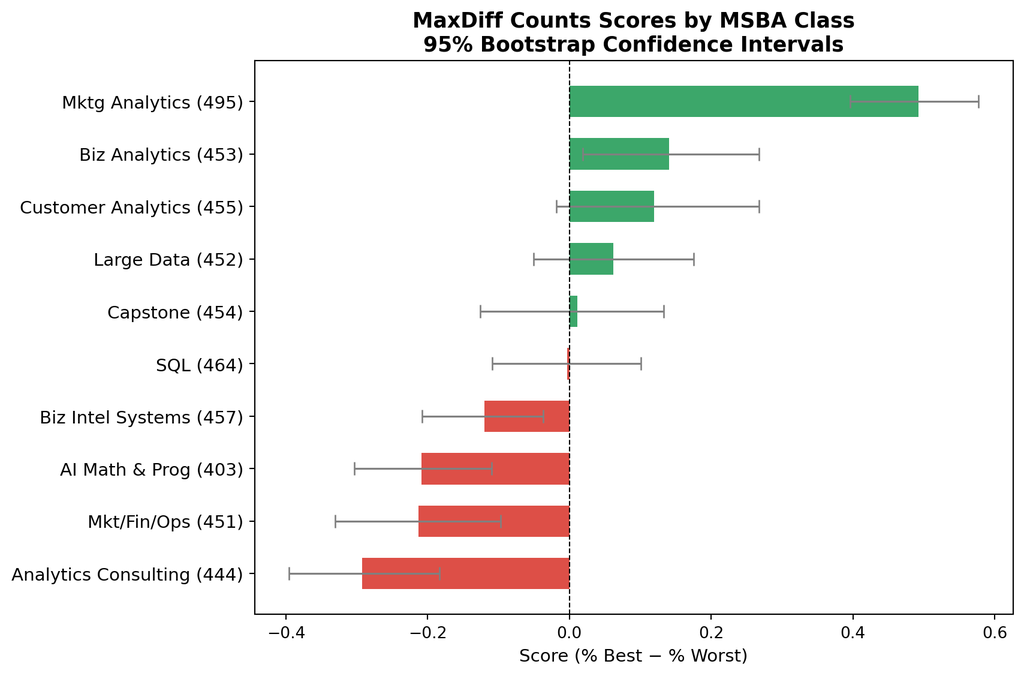

Counts scores with 95% bootstrap confidence intervals. Green = positive score (more often best than worst); red = negative.

```python
fig, ax = plt.subplots(figsize=(9, 6))
colors = ["#1a9850" if s > 0 else "#d73027" for s in counts_ci["score"]]
y_pos  = range(len(counts_ci))

ax.barh(list(y_pos), counts_ci["score"], color=colors, height=0.6, alpha=0.85)
ax.errorbar(counts_ci["score"], list(y_pos),
            xerr=[counts_ci["score"] - counts_ci["ci_lo"],
                  counts_ci["ci_hi"] - counts_ci["score"]],
            fmt="none", color="gray", capsize=4, linewidth=1.2)
ax.set_yticks(list(y_pos))
ax.set_yticklabels(counts_ci["short"], fontsize=11)
ax.axvline(0, color="black", linewidth=0.8, linestyle="--")
ax.set_xlabel("Score (% Best − % Worst)", fontsize=11)
ax.set_title("MaxDiff Counts Scores by MSBA Class\n95% Bootstrap Confidence Intervals",
             fontsize=13, fontweight="bold")
ax.invert_yaxis()
plt.tight_layout()
plt.show()
```

## From MaxDiff Data to MNL Choices

Before fitting a model, we need to understand how MaxDiff responses map to MNL choice observations.

The **Multinomial Logit (MNL)** model assigns each class $j$ a latent utility coefficient $\beta_j$. On a task showing items $\{a, b, c, d\}$, the probability item $b$ is picked *best* is the softmax:

$$P(\text{best} = b) = \frac{\exp(\beta_b)}{\exp(\beta_a) + \exp(\beta_b) + \exp(\beta_c) + \exp(\beta_d)}$$

After the best item is removed, the probability item $c$ is picked *worst* — using **negated** utilities since we are picking the least preferred — is:

$$P(\text{worst} = c \mid \text{best} = b) = \frac{\exp(-\beta_c)}{\exp(-\beta_a) + \exp(-\beta_c) + \exp(-\beta_d)}$$

Each task therefore yields **two** MNL observations: one for the best-pick from all 4 items, and one for the worst-pick from the remaining 3.

**Identifiability:** The softmax only depends on *differences* between utilities — adding the same constant to every $\beta$ leaves all probabilities unchanged. We can only identify $J - 1 = 9$ coefficients. We fix $\beta_1 = 0$ (AI Math & Programming as reference) and estimate $\beta_2, \ldots, \beta_{10}$.

```python
def build_tasks(df):
    tasks = []
    for (_, t), g in df.groupby(["record_id", "task"]):
        b = g[g["response"] ==  1]["item"].values
        w = g[g["response"] == -1]["item"].values
        if len(b) == 1 and len(w) == 1:
            tasks.append({"items": g["item"].tolist(),
                          "best":  int(b[0]),
                          "worst": int(w[0])})
    return tasks

tasks = build_tasks(df)
print(f"Tasks: {len(tasks)}  |  MNL observations: {len(tasks) * 2}")
```

```
Tasks: 680  |  MNL observations: 1360
```

## MNL via Maximum Likelihood

The log-likelihood summed over all tasks is:

$$\ell(\boldsymbol{\beta}) = \sum_{\text{tasks}} \left[ \beta_{j^*_b} - \log\sum_{j \in \text{shown}} \exp(\beta_j) \;-\; \beta_{j^*_w} - \log\sum_{j \in \text{shown} \setminus \{j^*_b\}} \exp(-\beta_j) \right]$$

where $j^*_b$ is the best-picked item and $j^*_w$ is the worst-picked item in each task.

```python
from scipy.optimize import minimize

def neg_ll(beta_free, tasks):
    beta  = np.concatenate([[0.0], beta_free])
    total = 0.0
    for t in tasks:
        items = np.array(t["items"]) - 1
        best  = t["best"]  - 1
        worst = t["worst"] - 1
        b     = beta[items]
        # numerically stable log-sum-exp
        total += beta[best]  - np.log(np.sum(np.exp(b - b.max()))) - b.max()
        rem    = items[items != best]
        b_rem  = -beta[rem]
        total += -beta[worst] - np.log(np.sum(np.exp(b_rem - b_rem.max()))) - b_rem.max()
    return -total

# Two-stage optimization: Nelder-Mead warm start → BFGS
res0 = minimize(neg_ll, np.zeros(9), args=(tasks,), method="Nelder-Mead",
                options={"maxiter": 20000, "xatol": 1e-9, "fatol": 1e-9})
res  = minimize(neg_ll, res0.x, args=(tasks,), method="BFGS",
                options={"maxiter": 5000, "gtol": 1e-7})

beta_hat   = np.concatenate([[0.0], res.x])
se_hat     = np.concatenate([[np.nan], np.sqrt(np.diag(res.hess_inv))])
shares_mle = np.exp(beta_hat) / np.exp(beta_hat).sum()

print(f"Log-likelihood at optimum: {-res.fun:.2f}")

mle_df = labels_raw.copy()
mle_df["beta"]  = beta_hat
mle_df["se"]    = se_hat
mle_df["share"] = shares_mle
mle_df.sort_values("share", ascending=False)[["item", "short", "beta", "se", "share"]].round(4)
```

```
Log-likelihood at optimum: -1572.73
```

|  | item | short | beta | se | share |
| --- | --- | --- | --- | --- | --- |
| 8 | 9 | Mktg Analytics (495) | 1.6298 | 0.1774 | 0.2839 |
| 4 | 5 | Biz Analytics (453) | 0.7445 | 0.1061 | 0.1171 |
| 6 | 7 | Customer Analytics (455) | 0.6563 | 0.1532 | 0.1072 |
| 3 | 4 | Large Data (452) | 0.5553 | 0.0290 | 0.0969 |
| 7 | 8 | Capstone (454) | 0.4433 | 0.1699 | 0.0867 |
| 1 | 2 | SQL (464) | 0.4380 | 0.2236 | 0.0862 |
| 9 | 10 | Biz Intel Systems (457) | 0.2359 | 0.1911 | 0.0704 |
| 0 | 1 | AI Math & Prog (403) | 0.0000 | NaN | 0.0556 |
| 2 | 3 | Mkt/Fin/Ops (451) | -0.0666 | 0.0573 | 0.0520 |
| 5 | 6 | Analytics Consulting (444) | -0.2388 | 0.1953 | 0.0438 |

The **shares of preference** $\hat{s}_j = \exp(\hat{\beta}_j) / \sum_k \exp(\hat{\beta}_k)$ convert raw $\beta$’s into an interpretable scale: if all 10 classes were shown on a single screen, what fraction of choices would each receive?

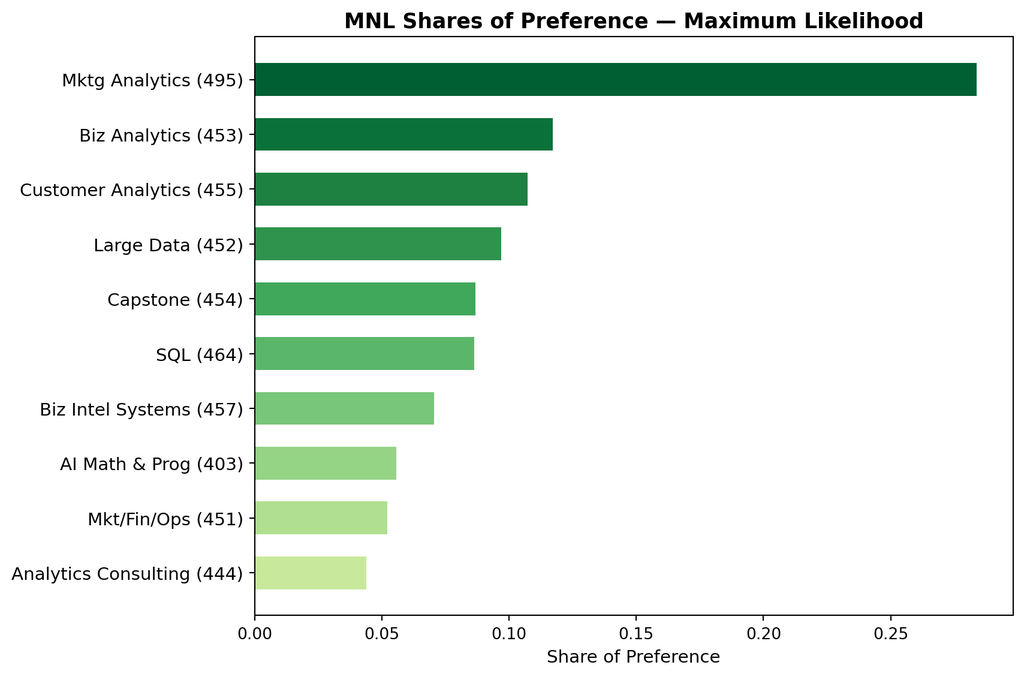

MLE shares of preference for each MSBA class.

```python
fig, ax = plt.subplots(figsize=(9, 6))
mle_sorted = mle_df.sort_values("share")
y_pos      = range(len(mle_sorted))
colors     = plt.cm.YlGn(np.linspace(0.3, 0.9, len(mle_sorted)))

ax.barh(list(y_pos), mle_sorted["share"], color=colors, height=0.6)
ax.set_yticks(list(y_pos))
ax.set_yticklabels(mle_sorted["short"], fontsize=11)
ax.set_xlabel("Share of Preference", fontsize=11)
ax.set_title("MNL Shares of Preference — Maximum Likelihood",
             fontsize=13, fontweight="bold")
plt.tight_layout()
plt.show()
```

## MNL via Bayesian Estimation

We now fit the same MNL model using **Bayesian methods**. The posterior is:

$$\pi(\boldsymbol{\beta} \mid \boldsymbol{y}) \propto L(\boldsymbol{\beta}) \cdot \pi(\boldsymbol{\beta})$$

We use a weakly informative prior $\boldsymbol{\beta} \sim \mathcal{N}(\mathbf{0},\; 10 \cdot I)$, which places a standard deviation of $\approx 3.2$ on each coefficient — diffuse enough not to distort the likelihood but informative enough to regularize extreme estimates.

```python
def log_post(beta_free, tasks):
    return -neg_ll(beta_free, tasks) + np.sum(-0.5 * beta_free**2 / 10.0)

def mh_sampler(beta0, n_iter, step, tasks, seed=42):
    np.random.seed(seed)
    K      = len(beta0)
    draws  = np.zeros((n_iter, K))
    beta   = beta0.copy()
    lp     = log_post(beta, tasks)
    accept = 0
    for t in range(n_iter):
        beta_star = beta + np.random.randn(K) * step
        lp_star   = log_post(beta_star, tasks)
        if np.log(np.random.rand()) < lp_star - lp:
            beta   = beta_star
            lp     = lp_star
            accept += 1
        draws[t] = beta
    return draws, accept / n_iter
```

```python
# Start from MLE estimates for efficiency
# Step size tuned to achieve ~25-40% acceptance rate:
# step=0.04 → ~55% (too high), step=0.15 → ~12% (too low), step=0.08 → ~28% (good)
draws, accept_rate = mh_sampler(res.x.copy(), n_iter=20000, step=0.08, tasks=tasks)

burn_in    = 5000  # discard first 25%
post_draws = draws[burn_in:]
print(f"Acceptance rate: {accept_rate:.1%}  (target: 25–40%)")
print(f"Post-burn-in draws: {len(post_draws):,}")
```

```
Acceptance rate: 29.1%  (target: 25–40%)
Post-burn-in draws: 15,000
```

The step size of `0.08` was tuned to yield an acceptance rate of approximately 28%, within the recommended 25–40% range. A step that is too large leads to frequent rejections and poor exploration; too small leads to slow mixing despite high acceptance.

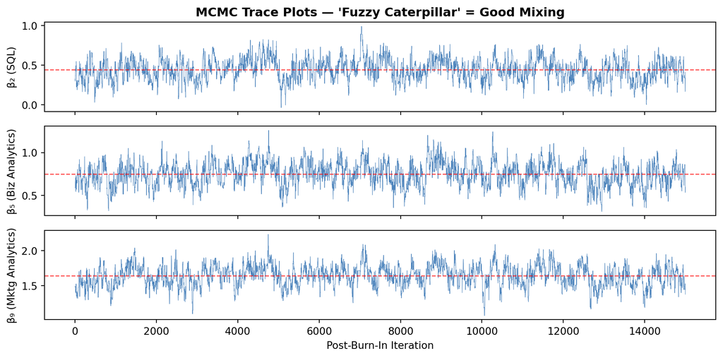

Trace plots for three β parameters after burn-in. The ‘fuzzy caterpillar’ pattern confirms good mixing and convergence.

```python
fig, axes = plt.subplots(3, 1, figsize=(10, 5), sharex=True)
param_names = ["β₂ (SQL)", "β₅ (Biz Analytics)", "β₉ (Mktg Analytics)"]
param_idx   = [0, 3, 7]

for ax, idx, name in zip(axes, param_idx, param_names):
    ax.plot(post_draws[:, idx], linewidth=0.4, alpha=0.8, color="#2166ac")
    ax.axhline(post_draws[:, idx].mean(), color="red", linewidth=1,
               linestyle="--", alpha=0.7)
    ax.set_ylabel(name, fontsize=10)

axes[-1].set_xlabel("Post-Burn-In Iteration")
axes[0].set_title("MCMC Trace Plots — 'Fuzzy Caterpillar' = Good Mixing",
                  fontsize=12, fontweight="bold")
plt.tight_layout()
plt.show()
```

```python
post_beta_full = np.hstack([np.zeros((len(post_draws), 1)), post_draws])

post_mean = post_beta_full.mean(axis=0)
post_lo   = np.percentile(post_beta_full, 2.5,  axis=0)
post_hi   = np.percentile(post_beta_full, 97.5, axis=0)

def softmax(x):
    e = np.exp(x - x.max())
    return e / e.sum()

shares_draws = np.apply_along_axis(softmax, 1, post_beta_full)
share_mean   = shares_draws.mean(axis=0)
share_lo     = np.percentile(shares_draws, 2.5,  axis=0)
share_hi     = np.percentile(shares_draws, 97.5, axis=0)

bayes_df = labels_raw.copy()
bayes_df["post_mean"] = post_mean
bayes_df["ci_lo"]     = post_lo
bayes_df["ci_hi"]     = post_hi
bayes_df["share"]     = share_mean
bayes_df["share_lo"]  = share_lo
bayes_df["share_hi"]  = share_hi
bayes_df = bayes_df.sort_values("share", ascending=False)

out = bayes_df[["item", "short", "post_mean", "ci_lo", "ci_hi", "share"]].copy()
out["95% CI"] = out.apply(lambda r: f"[{r.ci_lo:.3f}, {r.ci_hi:.3f}]", axis=1)
out[["item", "short", "post_mean", "95% CI", "share"]].round(4)
```

|  | item | short | post_mean | 95% CI | share |
| --- | --- | --- | --- | --- | --- |
| 8 | 9 | Mktg Analytics (495) | 1.6399 | [1.348, 1.915] | 0.2847 |
| 4 | 5 | Biz Analytics (453) | 0.7499 | [0.485, 1.003] | 0.1170 |
| 6 | 7 | Customer Analytics (455) | 0.6573 | [0.378, 0.926] | 0.1067 |
| 3 | 4 | Large Data (452) | 0.5628 | [0.306, 0.840] | 0.0971 |
| 7 | 8 | Capstone (454) | 0.4481 | [0.183, 0.713] | 0.0866 |
| 1 | 2 | SQL (464) | 0.4447 | [0.185, 0.703] | 0.0863 |
| 9 | 10 | Biz Intel Systems (457) | 0.2411 | [-0.020, 0.493] | 0.0704 |
| 0 | 1 | AI Math & Prog (403) | 0.0000 | [0.000, 0.000] | 0.0553 |
| 2 | 3 | Mkt/Fin/Ops (451) | -0.0565 | [-0.314, 0.227] | 0.0523 |
| 5 | 6 | Analytics Consulting (444) | -0.2400 | [-0.501, 0.014] | 0.0435 |

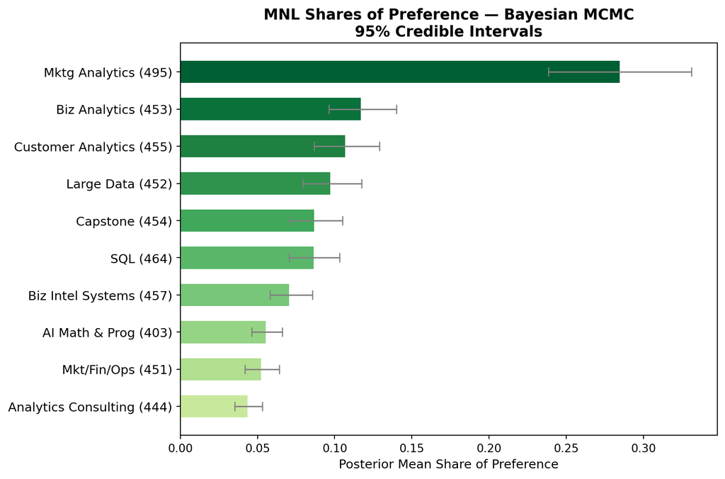

Bayesian posterior mean shares of preference with 95% credible intervals.

```python
fig, ax = plt.subplots(figsize=(9, 6))
bs     = bayes_df.sort_values("share")
y_pos  = range(len(bs))
colors = plt.cm.YlGn(np.linspace(0.3, 0.9, len(bs)))

ax.barh(list(y_pos), bs["share"], color=colors, height=0.6)
ax.errorbar(bs["share"], list(y_pos),
            xerr=[bs["share"] - bs["share_lo"], bs["share_hi"] - bs["share"]],
            fmt="none", color="gray", capsize=4, linewidth=1.2)
ax.set_yticks(list(y_pos))
ax.set_yticklabels(bs["short"], fontsize=11)
ax.set_xlabel("Posterior Mean Share of Preference", fontsize=11)
ax.set_title("MNL Shares of Preference — Bayesian MCMC\n95% Credible Intervals",
             fontsize=13, fontweight="bold")
plt.tight_layout()
plt.show()
```

## Comparing the Three Methods

```python
comp = labels_raw[["item", "short"]].copy()
comp = comp.merge(counts[["item", "score"]], on="item")
comp["counts_rank"] = comp["score"].rank(ascending=False).astype(int)
comp = comp.merge(mle_df[["item", "share"]].rename(columns={"share": "mle_share"}), on="item")
comp["mle_rank"] = comp["mle_share"].rank(ascending=False).astype(int)
comp = comp.merge(bayes_df[["item", "share"]].rename(columns={"share": "bayes_share"}), on="item")
comp["bayes_rank"] = comp["bayes_share"].rank(ascending=False).astype(int)
comp = comp.sort_values("mle_rank")

comp[["short", "score", "counts_rank", "mle_share", "mle_rank", "bayes_share", "bayes_rank"]].rename(
    columns={"short": "Class", "score": "Counts Score", "counts_rank": "Counts Rank",
             "mle_share": "MLE Share", "mle_rank": "MLE Rank",
             "bayes_share": "Bayes Share", "bayes_rank": "Bayes Rank"}
).round(4)
```

|  | Class | Counts Score | Counts Rank | MLE Share | MLE Rank | Bayes Share | Bayes Rank |
| --- | --- | --- | --- | --- | --- | --- | --- |
| 8 | Mktg Analytics (495) | 0.4927 | 1 | 0.2839 | 1 | 0.2847 | 1 |
| 4 | Biz Analytics (453) | 0.1407 | 2 | 0.1171 | 2 | 0.1170 | 2 |
| 6 | Customer Analytics (455) | 0.1196 | 3 | 0.1072 | 3 | 0.1067 | 3 |
| 3 | Large Data (452) | 0.0616 | 4 | 0.0969 | 4 | 0.0971 | 4 |
| 7 | Capstone (454) | 0.0110 | 5 | 0.0867 | 5 | 0.0866 | 5 |
| 1 | SQL (464) | -0.0036 | 6 | 0.0862 | 6 | 0.0863 | 6 |
| 9 | Biz Intel Systems (457) | -0.1203 | 7 | 0.0704 | 7 | 0.0704 | 7 |
| 0 | AI Math & Prog (403) | -0.2088 | 8 | 0.0556 | 8 | 0.0553 | 8 |
| 2 | Mkt/Fin/Ops (451) | -0.2132 | 9 | 0.0520 | 9 | 0.0523 | 9 |
| 5 | Analytics Consulting (444) | -0.2921 | 10 | 0.0438 | 10 | 0.0435 | 10 |

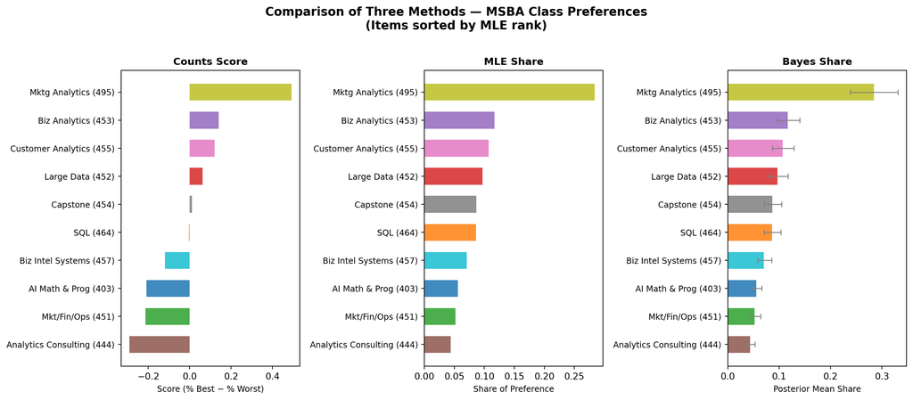

Side-by-side comparison of all three methods. Items are sorted by MLE rank. Colors are consistent across panels.

```python
item_order = mle_df.sort_values("share")["short"].tolist()

fig, axes = plt.subplots(1, 3, figsize=(14, 6))
palette   = plt.cm.tab10(np.linspace(0, 1, 10))
color_map = {s: palette[i] for i, s in enumerate(mle_df["short"])}

datasets = [
    (counts_ci.copy(),  "score", None,       None,       "Counts Score",  "Score (% Best − % Worst)"),
    (mle_df.copy(),     "share", None,       None,       "MLE Share",     "Share of Preference"),
    (bayes_df.copy(),   "share", "share_lo", "share_hi", "Bayes Share",   "Posterior Mean Share"),
]

for ax, (data, val, lo, hi, title, xlabel) in zip(axes, datasets):
    data = data.set_index("short").reindex(item_order)
    y    = range(len(data))
    clrs = [color_map[s] for s in data.index]
    ax.barh(list(y), data[val], color=clrs, height=0.6, alpha=0.85)
    if lo:
        ax.errorbar(data[val], list(y),
                    xerr=[data[val] - data[lo], data[hi] - data[val]],
                    fmt="none", color="gray", capsize=3, linewidth=1)
    ax.set_yticks(list(y))
    ax.set_yticklabels(data.index, fontsize=9)
    ax.set_title(title, fontsize=11, fontweight="bold")
    ax.set_xlabel(xlabel, fontsize=9)

fig.suptitle("Comparison of Three Methods — MSBA Class Preferences\n(Items sorted by MLE rank)",
             fontsize=13, fontweight="bold", y=1.01)
plt.tight_layout()
plt.show()
```

The MNL adds over counts by modeling the full choice process: every unselected item contributes information about *not* being picked, not just the items that were chosen. This makes the estimates more efficient.

The Bayesian approach adds over MLE by providing credible intervals on derived quantities like shares of preference — we simply push each MCMC draw through the softmax and take quantiles, with no delta method required. It also opens the door to hierarchical extensions that estimate individual-level preferences.

## Discussion

**Methodological takeaways:**

- *Counts*: Fast and intuitive, ideal for a quick executive dashboard. Limitation: ignores the structure of choice sets.
- *MLE MNL*: Rigorous point estimates with standard errors. Every unselected item contributes information. Good when a single defensible number is needed.
- *Bayesian MNL*: Full posterior uncertainty on derived quantities; extends naturally to hierarchical models for individual-level preference heterogeneity.

**Caveats:** This is a self-selected sample of MSBA students at one institution. Preferences likely depend on where students are in the program, prior work experience, and current course load. Results may not generalize beyond this group.

**Next steps:** A hierarchical Bayesian MNL (mixed logit) would reveal individual-level heterogeneity — for example, whether students with quantitative backgrounds have systematically different preferences from those with business or social science backgrounds.